# 005-diet_logging

# Diet logging dataset

### Description

Diet logging using a smartphone app involves collecting data on food and drink consumption through a mobile application. These data include information such as types of food, serving sizes, nutritional information and the times of consumption. The data is used to track dietary habits and can be used in scientific research to gain insights into the dietary habits of a population and to correlate to other temporal measurements and events.

### Introduction

There is a strong relationship between the development of chronic disease and a person’s diet. Adults who eat a healthy diet are more likely to live longer and are less likely to develop chronic disease or become obese. An unhealthy diet is a major risk factor for type 2 diabetes, cardiovascular disease and certain types of cancer. Consuming a nutrient-dense diet was associated with a low risk of all-cause mortality.

Nutritional epidemiology is a sub-discipline of epidemiology that provides data about the relationship between diet and disease. The data collected is used to define diet–disease associations that are converted into the practice of prevention by public-health nutrition practitioners. To study the associations between diet and disease, there is a need to accurately characterize the dietary habits of individuals. One approach is to use a food diary, which is a daily log of what an individual eats and drinks. Such diaries are used to characterize eating habits in large and small epidemiological studies. Owing to recent technological advancements and the vast availability of smartphones, nutrition-related apps are commonly used to track dietary behavior.

### Measurement protocol

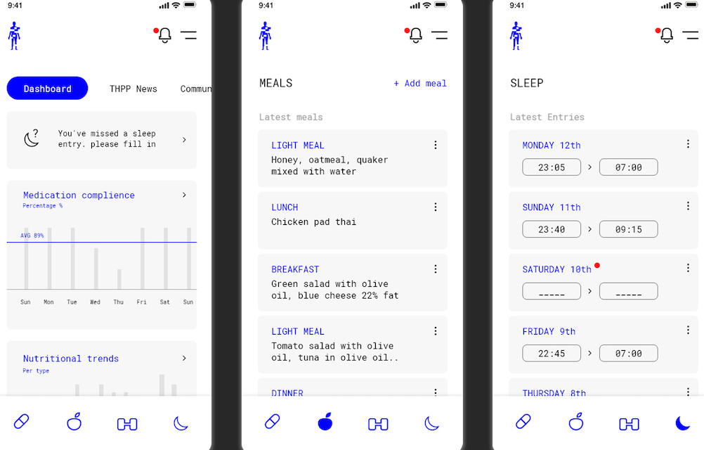

Participants are asked to download the app and start logging data one day before the visit to the assessment center. Participants are asked to log everything they eat and drink and to include as one “meal” all the items they have consumed within a 30 minute interval. While participants are asked to log their meals for at least 14 days after each visit, the logging app is open for the whole study period and participants are encouraged to document their diets beyond this time.

### Data availability:

The information is stored in 3 parquet files: `diet_logging.parquet`, `diet_logging_events.parquet`, `raw_diet_logging_events.parquet`which contains summary information, processed diet logging data and raw diet logging data respectively.

### Relevant links

- [Pheno Knowledgebase](https://knowledgebase.pheno.ai/datasets/005-diet_logging.html)
- [Pheno Data Browser](https://pheno-demo-app.vercel.app/folder/5)

```python
from pheno_utils import PhenoLoader
```

```python
pl = PhenoLoader('diet_logging')
pl
```

```
PhenoLoader for diet_logging with
10 fields
2 tables: ['diet_logging', 'age_sex']
```

# Data dictionary

```python
pl.dict
```

| tabular_field_name | field_string | description_string | folder_id | feature_set | field_type | strata | data_coding | array | pandas_dtype | bulk_file_extension | ... | stability | sexed | debut | completed | min_plausible_value | max_plausible_value | version | customer_field | dependency | parent_dataframe |
| --- | --- | --- | --- | --- | --- | --- | --- | --- | --- | --- | --- | --- | --- | --- | --- | --- | --- | --- | --- | --- | --- |
| collection_date | Date | Datetime column relecting the time food item w... | 5.0 | diet_logging | Datetime | Collection time | NaN | Single | datetime64[ns] | NaN | ... | Accruing | Both sexes | 2019-01-29 | NaN | NaN | NaN | NaN | NaN | NaN | NaN |
| logging_day | Logging day per participant | Integer indicating which day of logging period | 5.0 | diet_logging_events | Integer | Primary | NaN | Single | int | NaN | ... | Accruing | Both sexes | 2019-01-29 | NaN | NaN | NaN | NaN | NaN | NaN | NaN |
| total_logging_days | Total number of days logged | Total number of days diet was logged per resea... | 5.0 | diet_logging | Integer | Primary | NaN | Single | int | NaN | ... | Accruing | Both sexes | 2019-01-29 | NaN | NaN | NaN | NaN | NaN | NaN | NaN |
| timezone | Timezone | Timezone | 5.0 | diet_logging | Text | Collection time | NaN | Single | string | NaN | ... | Accruing | Both sexes | 2019-01-29 | NaN | NaN | NaN | NaN | NaN | NaN | NaN |
| food_items | Food items | Total number of food items logged per day | 5.0 | diet_logging | Integer | Primary | NaN | Single | int | NaN | ... | Accruing | Both sexes | 2019-01-29 | NaN | NaN | NaN | NaN | NaN | NaN | NaN |
| diet_logging_events | Diet logging events | File path to diet logging events | 5.0 | diet_logging_events | Time series file (group) | Auxiliary | NaN | Single | string | parquet | ... | Accruing | Both sexes | 2019-01-29 | NaN | NaN | NaN | NaN | NaN | NaN | NaN |
| raw_diet_logging_events | Raw diet logging events | File path to raw diet logging events | 5.0 | raw_diet_logging_events | Time series file (group) | Auxiliary | NaN | Single | string | parquet | ... | Accruing | Both sexes | 2019-01-29 | NaN | NaN | NaN | NaN | NaN | NaN | NaN |
| usda_sf_legacy_mapping | USDA SF Legacy nutritional mapping | Nutritional mapping file to USDA SF-Legacy dat... | 5.0 | diet_logging_auxiliary | Mapping table (group) | Auxiliary | NaN | Single | category | csv | ... | Accruing | Both sexes | 2019-01-29 | NaN | NaN | NaN | NaN | NaN | NaN | NaN |
| collection_timestamp | Collection timestamp | Collection timestamp | NaN | NaN | column | NaN | NaN | NaN | datetime64[ns, Asia/Jerusalem] | NaN | ... | Accruing | NaN | 2019-01-29 | NaN | NaN | NaN | NaN | ready | NaN | diet_logging_events |
| collection_date | Date | Datetime column relecting the time food item w... | NaN | NaN | column | NaN | NaN | NaN | datetime64[ns] | NaN | ... | Accruing | NaN | 2019-09-01 | NaN | NaN | NaN | NaN | ready | NaN | diet_logging_events |
| food_id | Food ID | IDs in the diet logging app representing speci... | NaN | NaN | column | NaN | NaN | NaN | int | NaN | ... | Accruing | NaN | 2019-09-01 | NaN | NaN | NaN | NaN | ready | NaN | diet_logging_events |
| weight_g | Weight | Weight of food item logged | NaN | NaN | column | NaN | NaN | NaN | float | NaN | ... | Accruing | NaN | 2019-09-01 | NaN | 0.0 | 2000.0 | NaN | ready | NaN | diet_logging_events |
| short_food_name | Short food name | Classifcation of food item logged into a short... | NaN | NaN | column | NaN | NaN | NaN | string | NaN | ... | Accruing | NaN | 2019-09-01 | NaN | NaN | NaN | NaN | ready | NaN | diet_logging_events |
| food_category | Food category | Classifcation of food item logged into a food ... | NaN | NaN | column | NaN | NaN | NaN | string | NaN | ... | Accruing | NaN | 2019-09-01 | NaN | NaN | NaN | NaN | ready | NaN | diet_logging_events |
| product_name | Product name | Product name of food logged | NaN | NaN | column | NaN | NaN | NaN | string | NaN | ... | Accruing | NaN | 2019-09-01 | NaN | NaN | NaN | NaN | ready | NaN | diet_logging_events |
| calories_kcal | Calories | Calories of food item logged | NaN | NaN | column | NaN | NaN | NaN | float | NaN | ... | Accruing | NaN | 2019-09-01 | NaN | 0.0 | 5000.0 | NaN | ready | NaN | diet_logging_events |
| carbohydrate_g | Carbohydrate intake per food logged | Carbohydrate intake per food logged | NaN | NaN | column | NaN | NaN | NaN | float | NaN | ... | Accruing | NaN | 2019-09-01 | NaN | NaN | NaN | NaN | ready | NaN | diet_logging_events |
| lipid_g | Fat intake per food logged | Fat intake per food logged | NaN | NaN | column | NaN | NaN | NaN | float | NaN | ... | Accruing | NaN | 2019-09-01 | NaN | NaN | NaN | NaN | ready | NaN | diet_logging_events |
| protein_g | Protein intake per food logged | Protein intake per food logged | NaN | NaN | column | NaN | NaN | NaN | float | NaN | ... | Accruing | NaN | 2019-09-01 | NaN | NaN | NaN | NaN | ready | NaN | diet_logging_events |
| sodium_mg | Sodium intake per food logged | Sodium intake per food logged | NaN | NaN | column | NaN | NaN | NaN | float | NaN | ... | Accruing | NaN | 2019-09-01 | NaN | NaN | NaN | NaN | ready | NaN | diet_logging_events |
| alcohol_g | Alcohol intake per food logged | Alcohol intake per food logged | NaN | NaN | column | NaN | NaN | NaN | float | NaN | ... | Accruing | NaN | 2019-09-01 | NaN | NaN | NaN | NaN | ready | NaN | diet_logging_events |
| dietary_fiber_g | Dietary fiber intake per food logged | Dietary fiber intake per food logged | NaN | NaN | column | NaN | NaN | NaN | float | NaN | ... | Accruing | NaN | 2019-09-01 | NaN | NaN | NaN | NaN | ready | NaN | diet_logging_events |
| local_timestamp | Local timestamp | Local timestamp of food logging | NaN | NaN | column | NaN | NaN | NaN | datetime64[ns] | NaN | ... | Accruing | NaN | 2019-09-01 | NaN | NaN | NaN | NaN | ready | NaN | diet_logging_events |
| eaten_in_restaurant | Eaten at restaurant indication | Indication if food was eatn at home or at a re... | NaN | NaN | column | NaN | NaN | NaN | bool | NaN | ... | Accruing | NaN | 2019-09-01 | NaN | NaN | NaN | NaN | ready | NaN | diet_logging_events |
| timezone | Timezone | Timezone | NaN | NaN | column | NaN | NaN | NaN | string | NaN | ... | Accruing | NaN | 2019-09-01 | NaN | NaN | NaN | NaN | ready | NaN | diet_logging_events |
| collection_timestamp | Collection timestamp | Collection timestamp | NaN | NaN | column | NaN | NaN | NaN | datetime64[ns, Asia/Jerusalem] | NaN | ... | Accruing | NaN | 2019-01-29 | NaN | NaN | NaN | NaN | ready | NaN | raw_diet_logging_events |
| collection_date | Date | Datetime column relecting the time food item w... | NaN | NaN | column | NaN | NaN | NaN | datetime64[ns] | NaN | ... | Accruing | NaN | 2019-09-01 | NaN | NaN | NaN | NaN | ready | NaN | raw_diet_logging_events |
| food_id | Food ID | IDs in the diet logging app representing speci... | NaN | NaN | column | NaN | NaN | NaN | int | NaN | ... | Accruing | NaN | 2019-09-01 | NaN | NaN | NaN | NaN | ready | NaN | raw_diet_logging_events |
| weight_g | Weight | Weight of food item logged | NaN | NaN | column | NaN | NaN | NaN | float | NaN | ... | Accruing | NaN | 2019-09-01 | NaN | 0.0 | 2000.0 | NaN | ready | NaN | raw_diet_logging_events |
| short_food_name | Short food name | Classifcation of food item logged into a short... | NaN | NaN | column | NaN | NaN | NaN | string | NaN | ... | Accruing | NaN | 2019-09-01 | NaN | NaN | NaN | NaN | ready | NaN | raw_diet_logging_events |
| food_category | Food category | Classifcation of food item logged into a food ... | NaN | NaN | column | NaN | NaN | NaN | string | NaN | ... | Accruing | NaN | 2019-09-01 | NaN | NaN | NaN | NaN | ready | NaN | raw_diet_logging_events |
| product_name | Product name | Product name of food logged | NaN | NaN | column | NaN | NaN | NaN | string | NaN | ... | Accruing | NaN | 2019-09-01 | NaN | NaN | NaN | NaN | ready | NaN | raw_diet_logging_events |
| calories_kcal | Calories | Calories of food item logged | NaN | NaN | column | NaN | NaN | NaN | float | NaN | ... | Accruing | NaN | 2019-09-01 | NaN | 0.0 | 5000.0 | NaN | ready | NaN | raw_diet_logging_events |
| carbohydrate_g | Carbohydrate intake per food logged | Carbohydrate intake per food logged | NaN | NaN | column | NaN | NaN | NaN | float | NaN | ... | Accruing | NaN | 2019-09-01 | NaN | NaN | NaN | NaN | ready | NaN | raw_diet_logging_events |
| lipid_g | Fat intake per food logged | Fat intake per food logged | NaN | NaN | column | NaN | NaN | NaN | float | NaN | ... | Accruing | NaN | 2019-09-01 | NaN | NaN | NaN | NaN | ready | NaN | raw_diet_logging_events |
| protein_g | Protein intake per food logged | Protein intake per food logged | NaN | NaN | column | NaN | NaN | NaN | float | NaN | ... | Accruing | NaN | 2019-09-01 | NaN | NaN | NaN | NaN | ready | NaN | raw_diet_logging_events |
| sodium_mg | Sodium intake per food logged | Sodium intake per food logged | NaN | NaN | column | NaN | NaN | NaN | float | NaN | ... | Accruing | NaN | 2019-09-01 | NaN | NaN | NaN | NaN | ready | NaN | raw_diet_logging_events |
| alcohol_g | Alcohol intake per food logged | Alcohol intake per food logged | NaN | NaN | column | NaN | NaN | NaN | float | NaN | ... | Accruing | NaN | 2019-09-01 | NaN | NaN | NaN | NaN | ready | NaN | raw_diet_logging_events |
| dietary_fiber_g | Dietary fiber intake per food logged | Dietary fiber intake per food logged | NaN | NaN | column | NaN | NaN | NaN | float | NaN | ... | Accruing | NaN | 2019-09-01 | NaN | NaN | NaN | NaN | ready | NaN | raw_diet_logging_events |
| local_timestamp | Local timestamp | Local timestamp of food logging | NaN | NaN | column | NaN | NaN | NaN | datetime64[ns] | NaN | ... | Accruing | NaN | 2019-09-01 | NaN | NaN | NaN | NaN | ready | NaN | raw_diet_logging_events |
| eaten_in_restaurant | Eaten at restaurant indication | Indication if food was eatn at home or at a re... | NaN | NaN | column | NaN | NaN | NaN | bool | NaN | ... | Accruing | NaN | 2019-09-01 | NaN | NaN | NaN | NaN | ready | NaN | raw_diet_logging_events |
| timezone | Timezone | Timezone | NaN | NaN | column | NaN | NaN | NaN | string | NaN | ... | Accruing | NaN | 2019-09-01 | NaN | NaN | NaN | NaN | ready | NaN | raw_diet_logging_events |

42 rows × 26 columns